# Depression Prevalence Analysis Report

MathisWo

2025-08-05

# 1. Project Overview

This project explores data on depression prevalence estimates from an IHME / Global Burden of Disease (GBD) dataset. For more information about the data and how to download it read the file “where_to_find_the_data.md” of my [Data Modeling Project](https://github.com/MathisWo/Data-Modeling-of-Global-Depression-Prevalence-Data).

The dataset contains the prevalence estimates of 204 countries/territories for every year from 1990 to 2021. The following sections show summary statistics and visualizations of the main insights. Please note that the country names are in german.

Load and clean the original depression prevalence dataset.

# 2. Main Insights

## 2.1 Prevalence over Time

### Global Average Prevalence Estimates over Time (1990-2021)

The global average prevalence of depression increases by a very small amount almost every year. The prevalence increases from 3.94% in 2019 to 4.37% in 2020. This bigger jump might be due to Covid19.

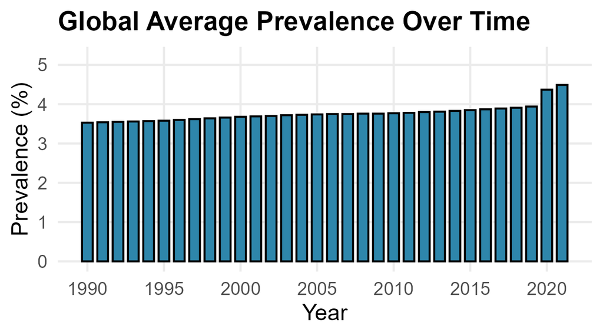

### Prevalence Estimates over Time in Germany (1990-2021)

The prevalence of depression in Germany follows a similar trend over time as the global average. In every year since 1990 the prevalence in Germany has been higher than the average trend line displayed in red.

2021: 5.04%

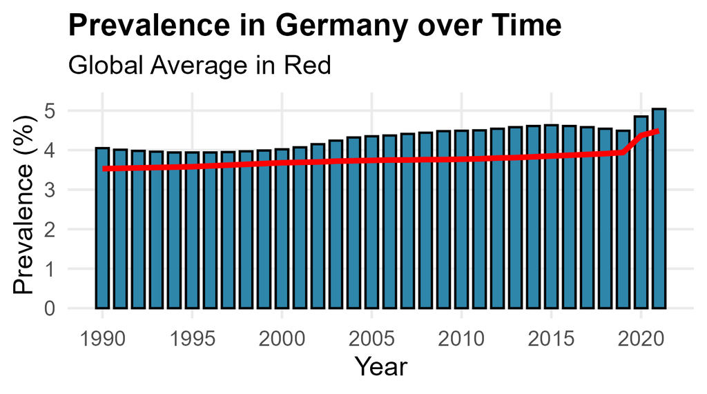

## 2.2 The Top 10 Countries with the Highest Prevalence of Depression

### Overall

This graph shows the top 10 countries with the highest average prevalence estimates from 1990-2021. Apart from Palastine (#4) and Tunisia (#8), eight out of the ten countries shown are european.

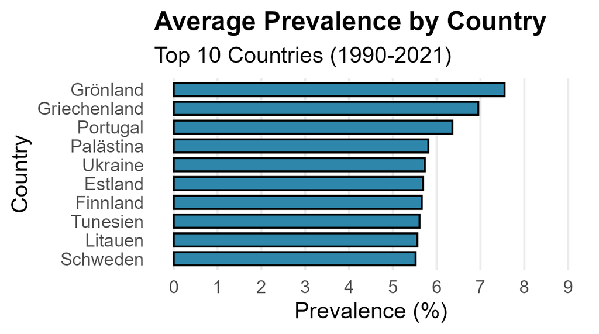

### In 2021

This graph shows the top 10 countries with the highest prevalence estimates in 2021. The values are consistently higher than the values averaged over the years. This reflects the increase over time shown in the first graph. In 2021 only 6 out of the ten countries are european. The other four are Tunisia (#3), Palastine (#5), Lebanon (#7) and Lesotho (#8).

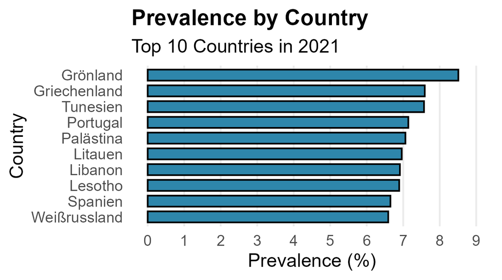

## 2.3 Prevalence Ranks

### Countries with the Highest and Lowest Prevalence for Every Year

The country with the highest prevalence estimate for depression alternates between Greenland and Greece from 1990 to 2021.

1990-1998: Greenland

1999-2003: Greece

2004-2021: Greenland

The country with the lowest prevalence of depression is Brunei for every year from 1990-2021. On average Brunei has a prevalence of 1.8%.

### Germany’s Rank

On average (1990-2021) Germany shows the 54th highest prevalence of depression.

In 2021 Germany lands on Rank 61.

## 3. Summary

- The prevalence of depression increased slightly from 1990 to 2021
- Germany has a higher prevalence than the global average in every year with a prevalence of 5.04% in 2021 (Rank 54 overall, Rank 61 in 2021)
- Most of the top 10 countries with the highest average prevalence estimates are european
- Greenland and Greece show the highest prevalence estimates over the years
- Brunei shows the lowest prevalence estimates in every year with an average of 1.8%